# Assignment 3

PUBH 7462

Author

Patrick Torralba

## Instructions

In this assignment, you’ll practice writing functions and doing iteration while building a system that automatically converts the coded ATUS data values into “friendly” labels using a data dictionary.

As in previous assignments, there are no individual “questions” on this assignment, just a set of tasks to complete. If you complete the set of tasks, you will receive the full 50 points for the assignment. Partial credit will be awarded if you’re unable to complete all of the tasks.

## Task #1: Download files from Canvas

## Task #2: Load the ATUS data and data dictionary

You should create the `data` folder that contains two files:

- `atus_raw.csv` is the “raw” ATUS data. In this dataset, categorical variables use numerical codes, which are documented in the data dictionary.
- `atus_dictionary.csv` is a data file contains information about the variables in the ATUS dataset, derived from the original data dictionary (available in the `docs` folder as `atus_dictionary.doc`). This is an example of a “data dictionary as data”, which as we’ll see is a very useful concept as it will allow us to automate a lot of data processing.

## Task #3: Explore the data dictionary data

After loading `atus_dictionary.csv`, spend a minute familiarizing yourself with its structure. You’ll notice that it’s in long format, with levels of categorical variables each getting their own row. The `type` column indicates whether the variable is `categorical` or `numeric`. `categorical` variables have entries in the `value` and `label` column; the `value` column gives the numeric code as found in `atus_raw.csv`, while the `label` column gives the “friendly” label corresponding to that numeric code. `numeric` variables have both `value` and `label` recorded as missing (`NA`). All variables in `atus_raw.csv` are documented *except the activity variables (starting with `ACT_`*)*.*

**Aside:** A “data dictionary as data” intended for public consumption would ideally also a brief description of each variable as well. You can find these descriptions, if needed, in `atus_dictionary.doc` word document.

Produce the following plot, which shows the distribution of number of levels for the categorical variables in the dataset:

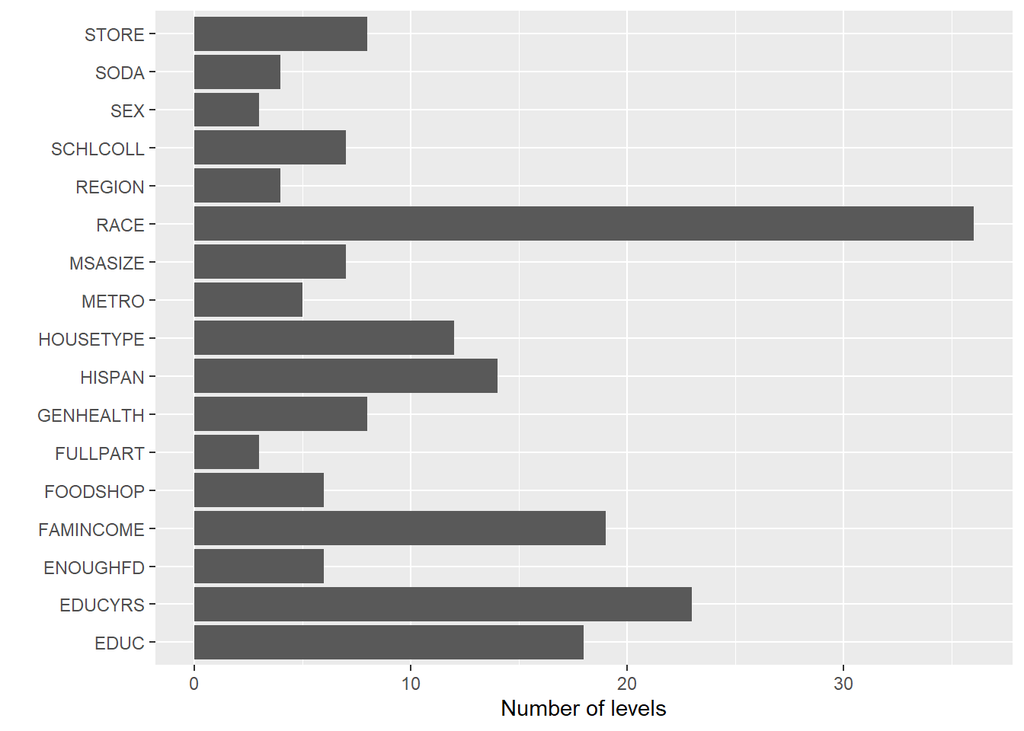

**Optional Challenge**

Produce a version of the plot with the categories in order from most to least levels:

## Task #4: Write a function to translate codes into friendly labels

Write a function, `make_labels`, which has the following form:

```r
make_labels <- function(x, values, labels) {
  # Your code here...
}
```

The function’s three arguments are:

- `x`, an input vector consisting of coded values
- `values` , the unique set of coded values that `x` could potentially take on
- `labels` , the labels corresponding to the entries in `values`

The function should return a “friendly” version of `x`, i.e., a factor with the coded values in `x` replaced by the labeled values.

For example, given a vector `make_labels` should produce the following:

```r
#MODIFY - uncomment 'make_labels' when finished
x <- c(0, 0, 0, 1, 0, 1)
values <- c(0, 1, 2)
labels <- c("Male", "Female", "Prefer Not to Say")

make_labels(x, values, labels)
```

```
[1] Male   Male   Male   Female Male   Female
Levels: Male Female Prefer Not to Say
```

Test your function using the `GENHEALTH` variable from the ATUS dataset.

```
    [1] Excellent Very good Poor      Very good Fair      <NA>      Good
    [8] Very good Very good Good      Excellent Fair      Good      Good
   [15] Good      Very good Good      Very good Very good Very good Fair
   [22] Very good Good      Very good Poor      Fair      Good      Very good
   [29] Excellent Very good Very good Very good Good      Very good Very good
   [36] Very good Excellent Very good Good      Very good Poor      Very good
   [43] Excellent Good      Fair      Excellent Very good Good      Fair
   [50] Excellent Fair      Good      Good      Very good Fair      Good
   [57] Very good Very good Good      Very good Fair      Very good Very good
   [64] Good      Very good Good      Good      Very good Very good Good
   [71] Very good Good      Very good Fair      Very good Good      Very good
   [78] Good      Good      Good      Good      Very good Good      Fair
   [85] Good      <NA>      Good      Very good Very good Fair      Fair
   [92] Good      Excellent Good      Very good Fair      Good      Good
   [99] Good      Very good Good      Very good Good      Good      Very good
```

[output cut: 1642 more lines]

## Task #5: Make `make_labels` more error-proof

Improve the `make_labels` function by implementing the following checks (with helpful error messages):

- Produce an error if `values` and `labels` have different lengths
- Produce a warning if there are any values in `x` that do not appear in `values`. The warning should tell the user that these values will appear as missing (`NA`) in the output.

## Task #6: Write a function to make labels for any variable in a data dictionary

Now, suppose that we want to return the “friendly” labels for any column of a data frame that we specify by name. Write a function with the following signature:

```r
# MODIFY
label_from_dict <- function(v_name, data, dict) {
}
```

The arguments are:

- `v_name`, the name of a variable
- `data`, the data frame (or tibble) that the variable appears in
- `dict`, a data dictionary structured the same way as the one you read in above

Check that your function works by confirming that you get this output from the following code:

```r
income <- label_from_dict("FAMINCOME", atus, atus_dict)

region <- label_from_dict("REGION", atus, atus_dict)
table(income, region)
```

```
                      region
income                 Northeast Midwest South West
  Less than $5,000            45      78   118   54
  $5,000 to $7,499            21      38    77   33
  $7,500 to $9,999            48      60   149   57
  $10,000 to $12,499          66      91   165   78
  $12,500 to $14,999          52      84   125   76
  $15,000 to $19,999          70     125   219  124
  $20,000 to $24,999         105     156   318  139
  $25,000 to $29,999         110     163   274  130
  $30,000 to $34,999         101     178   282  126
  $35,000 to $39,999         102     157   228  155
  $40,000 to $49,999         170     265   358  216
  $50,000 to $59,999         156     240   323  201
  $60,000 to $74,999         203     303   408  264
  $75,000 to $99,999         220     351   482  290
  $100,000 to $149,999       265     319   430  305
  $150,000 and over          235     199   326  286
  Refused                      0       0     0    0
  Don't know                   0       0     0    0
  Blank                        0       0     0    0
```

Write the `label_from_dict` function so that the “work” is done by a call to the `make_labels` function that you defined above.

**Optional challenge**

The `label_from_dict` function assumes that the relevant columns of `dict` are named `variable`, `value`, and `label`. This isn’t very generalizable. Write a version of the `label_from_dict` function which takes three additional arguments, `variable_var`, `value_var`, and `label_var`, which are each strings that give the name of the respective columns in `dict`. Set their default values to be “variable”, “value”, and “label” so that your new function will work in the rest of the assignment.

HINT: The command `filter(!!sym(variable_var) == v_name)` will do exactly the same thing as `filter(variable == v_name)`; the same thing applies for `!!sym(value_var)` and `!!sym(label_var)`. See the code in the “My recommendation (& a bonus function!)” box at the end of the assignment for an example of how to use this syntax.

Test your function by renaming the columns of `atus_dict` and running your new function on it.

## Task #7: Improve `label_from_dict`

Implement error checking by writing code that stops execution (with a useful error message) if:

- `v_name` doesn’t appear in either `data` and `dict`
- `v_name` is not a categorical variable

## Task #8: Apply `label_from_dict` to all the categorical variables in your dataset

- `data`, the data frame
- `dict`, the data dictionary

The function `label_all_from_dict` should return a data frame (or tibble) with all the categorical variables having their coded values replaced by “friendly” ones pulled form the data dictionary.

HINT: While you’re not obligated to follow my approach for this problem, here’s a rough sketch of how my `label_all_from_dict` function works:

- Create a vector, `cat_vars`, containing the names of the categorical variables from `dict`
- Use the `map_dfc` function to apply the `label_from_dict` function to `cat_vars`. The syntax I used is: `map_dfc(cat_vars, .f = label_from_dict, data = data, dict = dict)`
  - For more on the `map` family of functions, see the last part of the Week 4 lecture.
- Assign the correct column names to the result of the `map_dfc` command using the `colnames` function.
- Bind the resulting columns to the set of columns which were not modified by `label_from_dict`

**Optional challenges**

- Add error checking to the `label_all_from_dict` function
- Implement the `variable_var`, `value_var`, and `label_var` arguments as above
- Return the columns of the output data frame in the same order as the original data frame

## Task #9: Submit and reflect

Submit your qmd file and html output to Canvas.

Now, **take a step back to look at what you’ve done**: with a couple of dozen lines of code (hopefully), you’ve created a set of functions that can automatically add “friendly” labels to all the categorical variables of any dataset. Doing this manually would have take hundreds of lines! The only thing you need is a “data dictionary as data”, i.e., a data file with the same layout as `atus_dictionary.csv` that maps the variable codes to labels.

**Recommendation (& a bonus function!)**

If you have the opportunity to give input in the early stages of data collection, you should *advocate for the data dictionary to be constructed as a data file*, thereby allowing you to apply the type of code you developed here to make your data processing life much easier.

A good data dictionary as data file brings other benefits, too. For example, the `type` column in the data dictionary allows you to write generic functions for doing things like creating summary tables and plots that operate differently depending on the data type.

Consider the following code, which produces a different summary plot depending on whether the named variable is categorical or numeric. The code uses some fancy footwork (the `!!sym(v_name)` command) to convert the `v_name` string into a “naked” variable name, but otherwise is pretty straightforward.

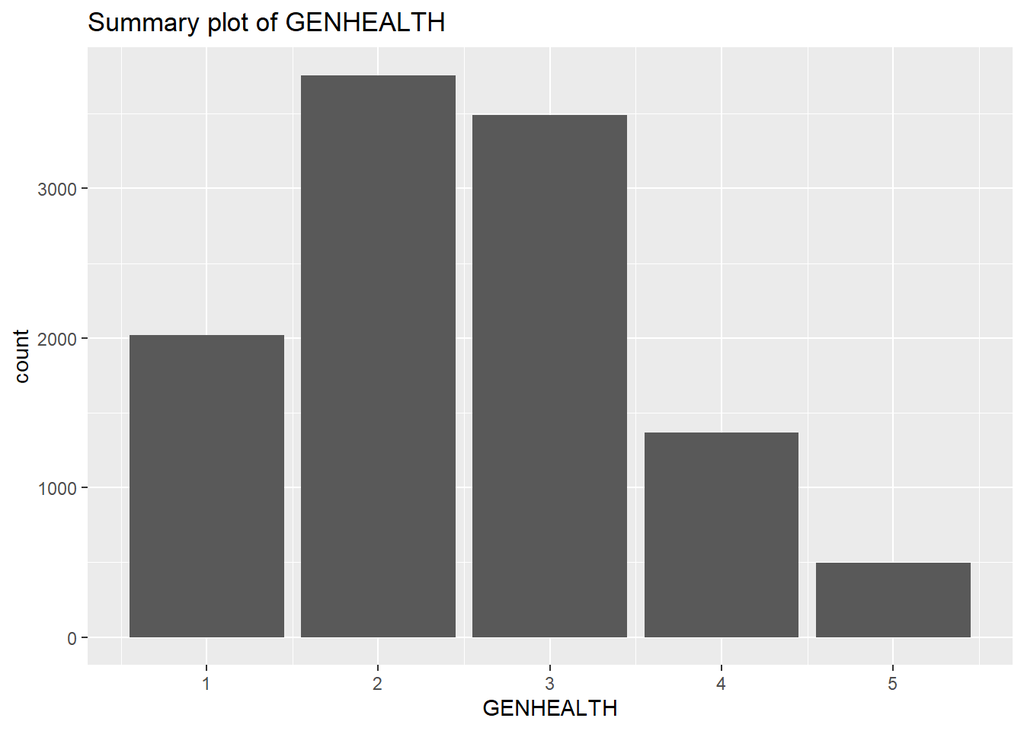

```r
summary_plot <- function(v_name, data, dict) {
  # Get the variable type
  var_type <- dict %>% filter(variable == v_name) %>% pull(type) %>% first()

  # !!sym(vname) converts the string v_name into a variable name that
  # ggplot knows how to deal with.
  # For example, if v_name is the string "GENHEALTH", then
  # aes(x = !!sym(v_name)) is like typing aes(x = GENHEALTH)
  base_plot <- data %>% ggplot(aes(x = !!sym(v_name)))

  if(var_type == "categorical") {
    # For categorical variables, make a bar plot
    final_plot <- base_plot + geom_bar()
  } else {
    # For numeric variables, make a density plot
    final_plot <- base_plot + geom_density()
  }

  return(final_plot + ggtitle(paste("Summary plot of", v_name)))

}

summary_plot("GENHEALTH", atus, atus_dict)
```

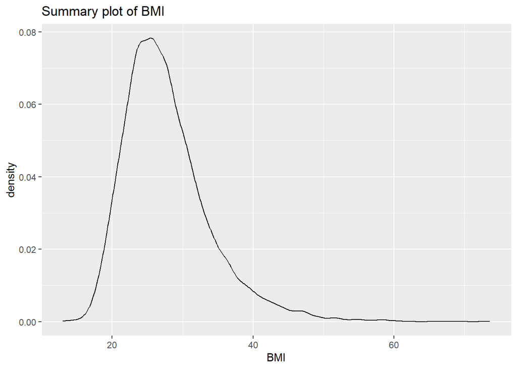

```r
summary_plot("BMI", atus, atus_dict)
```

**A bonus to the bonus**

Wouldn’t it be cool if we could convert our `summary_plot` function to work in a dplyr pipeline, so that we could call it like this?

```r
atus %>% summary_plot(GENHEALTH, dict = atus_dict)
atus %>% summary_plot(BMI, dict = atus_dict)
```

Turns out, you can! Here is the modified function, which involves just a little more fancy footwork.

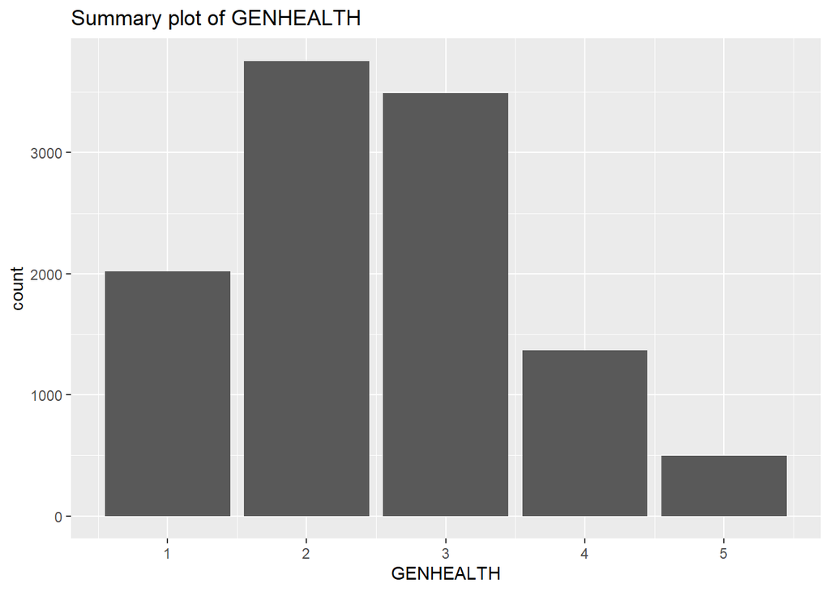

```r
summary_plot <- function(data, v_name, dict) {
  # Get the variable type
  # We have to use rlang::as_name(v_name) to convert it to a string
  v_name_str <- rlang::as_name(enquo(v_name))

  var_type <- dict %>% filter(variable == v_name_str) %>% pull(type) %>% first()

  # !!sym(vname) converts the string v_name into a variable name that
  # ggplot knows how to deal with.
  # For example, if v_name is the string "GENHEALTH", then
  # aes(x = !!sym(v_name)) is like typing aes(x = GENHEALTH)
  base_plot <- data %>% ggplot(aes(x = !!sym(v_name_str)) )

  if(var_type == "categorical") {
    # For categorical variables, make a bar plot
    final_plot <- base_plot + geom_bar()
  } else {
    # For numeric variables, make a density plot
    final_plot <- base_plot + geom_density()
  }

  return(final_plot + ggtitle(paste("Summary plot of", v_name_str)))

}

atus %>% summary_plot(GENHEALTH, dict = atus_dict)
```

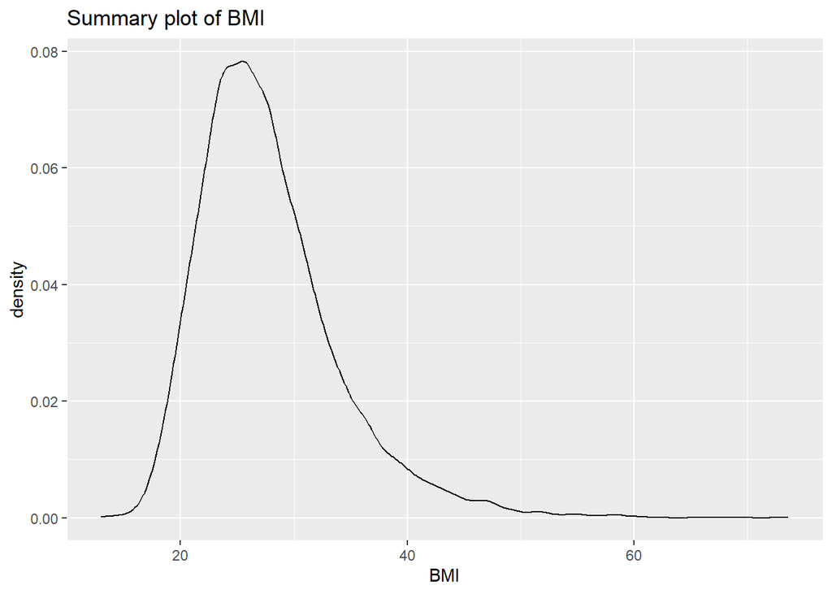

```r
atus %>% summary_plot(BMI, dict = atus_dict)
```